# Determining Whether or Not Someone Is a Good Credit Card Candidate

#### PSTAT 131, Anirudh Balepur

- Introduction
- Data Loading
- Exploratory Data Analysis
  - Application Dataset
  - Credit Dataset
  - Dummify and Scale Explanatory Variables
    - Missing Data?
  - Outcome Variable and Its Criteria
- Finalizing Our Model Selection Dataset
- Feature Selection and Train/Test Split
  - Metric Evaluation
- Logistic Regression Model
  - Oversampling Data
  - K-Fold Cross Validation
- Quadratic Discriminant Analysis
  - Oversampling Data
  - K-Fold Cross Validation
- XGBoost Model
  - Oversample Data
  - K-Fold Cross Validation
  - Hyperparameter Tuning
  - K-fold Cross Validation on Hyperparameter-Tuned Model
- Random Forest Model
  - Oversample Data
  - K-Fold Cross Validation
  - Hyperparameter Tuning
  - K-fold Cross Validation on Hyperparameter-Tuned Model
- Model Selection
- Final Model Evaluation
  - XGBoost
    - Confusion Matrix
  - Random Forest
    - Confusion Matrix
- Conclusion and Findings

# Introduction

In this project, I will use machine learning models to determine if someone is a good credit card candidate or not.

Before we begin, let’s understand how credit cards work and the business decisions a Credit Card company (CC) needs to make. Credit cards allow the cardholder to spend money on “credit,” essentially borrowing money they may not have immediately but can pay back over time. Cardholders benefit from the obvious convenience of credit cards and often also enjoy other cash back or travel-related rewards the card company offers. The cardholder, on the other hand, is expected to pay the CC company the outstanding balance back.

The CC makes money by a) charging an interest on any outstanding / unpaid balance past the first payment period, b) levying late fees when the cardholder fails to make the minimum payment by the due date and c) through “interchange” fees paid by merchants on every transaction. Like with any loan, there’s risk that the borrower is unable to pay the CC back and they are “delinquent”, ie., late in their payment or even in “default”, ie., unlikely to pay the outstanding back. While some delinquency is economically beneficial to the CC (due to interest charges and late fees), too much of it is not.

So, a CC has to understand that risk and reward tradeoff right upfront and only approve applicants / borrowers who meet certain criteria and where the CC can “price” for the risk. To do so, a CC typical develops a Credit Risk model and a Valuation model and then use them in conjunction to establish decision criteria for approval. The Credit Risk Model attempts to discriminate between good and bad applicants, where a “bad” applicant is likely to default and a “good’ one is not. Valuation Models predict the expected “lifetime value” (in terms of income or profits) a borrower will generate for the CC In this exercise, we’ll only concern ourselves with the former, ie., a Credit Risk model.

I got my data from a [kaggle dataset](https://www.kaggle.com/datasets/rikdifos/credit-card-approval-prediction/data) which consists of two different datasets, as described below: a) Application Data: A file with one record per applicant with various features about the applicant b) Credit Data: A file with one record per applicant (borrower) per month (pay period) indicating whether the cardholder / borrower had a balance in that month and whether or how delinquent they were

I am framing this as a “binary” classifcation problem to discriminate between “good” applicants vs. “bad” applicants purely based on their likelihood to repay / not default. As noted previously, the “valuation” part of the equation will be ignored.

I will evaluate different machine learning models to find one that does the best job of discriminating between the “bads” and the “goods”.

Let's now jump into the data.

# Data Loading

I will start by loading the appropriate packages, as well as reading the csv files.

```python
import pandas as pd
import numpy as np
import seaborn as sns
import matplotlib.pyplot as plt
import sklearn
```

```python
application = pd.read_csv("/Users/_ovoani_/Downloads/131_project/application_record.csv")
credit = pd.read_csv("/Users/_ovoani_/Downloads/131_project/credit_record.csv")
```

```python
application.head()
```

|  | ID | CODE_GENDER | FLAG_OWN_CAR | FLAG_OWN_REALTY | CNT_CHILDREN | AMT_INCOME_TOTAL | NAME_INCOME_TYPE | NAME_EDUCATION_TYPE | NAME_FAMILY_STATUS | NAME_HOUSING_TYPE | DAYS_BIRTH | DAYS_EMPLOYED | FLAG_MOBIL | FLAG_WORK_PHONE | FLAG_PHONE | FLAG_EMAIL | OCCUPATION_TYPE | CNT_FAM_MEMBERS |
| --- | --- | --- | --- | --- | --- | --- | --- | --- | --- | --- | --- | --- | --- | --- | --- | --- | --- | --- |
| 0 | 5008804 | M | Y | Y | 0 | 427500.0 | Working | Higher education | Civil marriage | Rented apartment | -12005 | -4542 | 1 | 1 | 0 | 0 | NaN | 2.0 |
| 1 | 5008805 | M | Y | Y | 0 | 427500.0 | Working | Higher education | Civil marriage | Rented apartment | -12005 | -4542 | 1 | 1 | 0 | 0 | NaN | 2.0 |
| 2 | 5008806 | M | Y | Y | 0 | 112500.0 | Working | Secondary / secondary special | Married | House / apartment | -21474 | -1134 | 1 | 0 | 0 | 0 | Security staff | 2.0 |
| 3 | 5008808 | F | N | Y | 0 | 270000.0 | Commercial associate | Secondary / secondary special | Single / not married | House / apartment | -19110 | -3051 | 1 | 0 | 1 | 1 | Sales staff | 1.0 |
| 4 | 5008809 | F | N | Y | 0 | 270000.0 | Commercial associate | Secondary / secondary special | Single / not married | House / apartment | -19110 | -3051 | 1 | 0 | 1 | 1 | Sales staff | 1.0 |

```python
credit.head()
```

|  | ID | MONTHS_BALANCE | STATUS |
| --- | --- | --- | --- |
| 0 | 5001711 | 0 | X |
| 1 | 5001711 | -1 | 0 |
| 2 | 5001711 | -2 | 0 |
| 3 | 5001711 | -3 | 0 |
| 4 | 5001712 | 0 | C |

I've compiled a [codebook](https://docs.google.com/document/d/1vTUBlry6yOkY44HCORgFitfixAjCSoy-sxo110zCQxE/edit?usp=sharing) explaining all the variables in the application and credit datasets. The one thing we can immediately notice is that both datasets have the ID column, which will be useful later on for merging the datasets.

We're now ready for some data analysis.

# Exploratory Data Analysis

In this section, I will be cleaning data and making graphs of various variables so that we can better understand the data.

## Application Dataset

There are a few things I want to change based on the codebook above.

```python
#DAYS_BIRTH and DAYS_EMPLOYED are negative values, let's change that
application['AGE'] = application['DAYS_BIRTH']*-1/365
application['YEARS_EMPLOYED'] = application['DAYS_EMPLOYED']*-1/365
application = application.drop(columns = ['DAYS_BIRTH', 'DAYS_EMPLOYED'])
application.head()
```

|  | ID | CODE_GENDER | FLAG_OWN_CAR | FLAG_OWN_REALTY | CNT_CHILDREN | AMT_INCOME_TOTAL | NAME_INCOME_TYPE | NAME_EDUCATION_TYPE | NAME_FAMILY_STATUS | NAME_HOUSING_TYPE | FLAG_MOBIL | FLAG_WORK_PHONE | FLAG_PHONE | FLAG_EMAIL | OCCUPATION_TYPE | CNT_FAM_MEMBERS | AGE | YEARS_EMPLOYED |
| --- | --- | --- | --- | --- | --- | --- | --- | --- | --- | --- | --- | --- | --- | --- | --- | --- | --- | --- |
| 0 | 5008804 | M | Y | Y | 0 | 427500.0 | Working | Higher education | Civil marriage | Rented apartment | 1 | 1 | 0 | 0 | NaN | 2.0 | 32.890411 | 12.443836 |
| 1 | 5008805 | M | Y | Y | 0 | 427500.0 | Working | Higher education | Civil marriage | Rented apartment | 1 | 1 | 0 | 0 | NaN | 2.0 | 32.890411 | 12.443836 |
| 2 | 5008806 | M | Y | Y | 0 | 112500.0 | Working | Secondary / secondary special | Married | House / apartment | 1 | 0 | 0 | 0 | Security staff | 2.0 | 58.832877 | 3.106849 |
| 3 | 5008808 | F | N | Y | 0 | 270000.0 | Commercial associate | Secondary / secondary special | Single / not married | House / apartment | 1 | 0 | 1 | 1 | Sales staff | 1.0 | 52.356164 | 8.358904 |
| 4 | 5008809 | F | N | Y | 0 | 270000.0 | Commercial associate | Secondary / secondary special | Single / not married | House / apartment | 1 | 0 | 1 | 1 | Sales staff | 1.0 | 52.356164 | 8.358904 |

```python
#check bc of formulas
print(len(application[application['AGE'] < 0]))
print(len(application[application['YEARS_EMPLOYED'] < 0]))
```

```
0
75329
```

```python
#people with negative YEARS_EMPLOYED are unemployed, let's set them to 0
application.loc[application['YEARS_EMPLOYED'] < 0, 'YEARS_EMPLOYED'] = 0
print(len(application[application['AGE'] < 0]))
print(len(application[application['YEARS_EMPLOYED'] < 0]))
```

```
0
0
```

```python
#check for duplicates in application, start by looking @ dimensions
app_rows, app_cols = application.shape
print(app_rows)
print(app_cols)
#we have 438,557 rows and 18 columns in the application data set. lets do the same for the credit data set
credit_rows, credit_cols = credit.shape
print(credit_rows)
print(credit_cols)
#we have 1,058,575 rows and 3 columns in the credit data set.
```

```
438557
18
1048575
3
```

```python
application_clean = application.drop_duplicates(subset = 'ID', keep = False, inplace = False)
application_clean.info()
```

```
<class 'pandas.core.frame.DataFrame'>
Int64Index: 438463 entries, 0 to 438556
Data columns (total 18 columns):
 #   Column               Non-Null Count   Dtype
---  ------               --------------   -----
 0   ID                   438463 non-null  int64
 1   CODE_GENDER          438463 non-null  object
 2   FLAG_OWN_CAR         438463 non-null  object
 3   FLAG_OWN_REALTY      438463 non-null  object
 4   CNT_CHILDREN         438463 non-null  int64
 5   AMT_INCOME_TOTAL     438463 non-null  float64
 6   NAME_INCOME_TYPE     438463 non-null  object
 7   NAME_EDUCATION_TYPE  438463 non-null  object
 8   NAME_FAMILY_STATUS   438463 non-null  object
 9   NAME_HOUSING_TYPE    438463 non-null  object
 10  FLAG_MOBIL           438463 non-null  int64
 11  FLAG_WORK_PHONE      438463 non-null  int64
 12  FLAG_PHONE           438463 non-null  int64
 13  FLAG_EMAIL           438463 non-null  int64
 14  OCCUPATION_TYPE      304286 non-null  object
 15  CNT_FAM_MEMBERS      438463 non-null  float64
 16  AGE                  438463 non-null  float64
 17  YEARS_EMPLOYED       438463 non-null  float64
dtypes: float64(4), int64(6), object(8)
memory usage: 63.6+ MB
```

```python
print(application_clean)
```

```
             ID CODE_GENDER FLAG_OWN_CAR FLAG_OWN_REALTY  CNT_CHILDREN  \
0       5008804           M            Y               Y             0
1       5008805           M            Y               Y             0
2       5008806           M            Y               Y             0
3       5008808           F            N               Y             0
4       5008809           F            N               Y             0
...         ...         ...          ...             ...           ...
438552  6840104           M            N               Y             0
438553  6840222           F            N               N             0
438554  6841878           F            N               N             0
438555  6842765           F            N               Y             0
438556  6842885           F            N               Y             0

        AMT_INCOME_TOTAL      NAME_INCOME_TYPE            NAME_EDUCATION_TYPE  \
0               427500.0               Working               Higher education
```

[output cut: 51 more lines]

Checking for things like duplicates is important because they make the merging process harder and are overall errors and flaws within the dataset. As we can see, we went from 438557 entries in the original application dataset to 438463 in the cleaned dataset. Now that we've cleaned our data, let's make a correlation matrix of the variables in the cleaned application dataset.

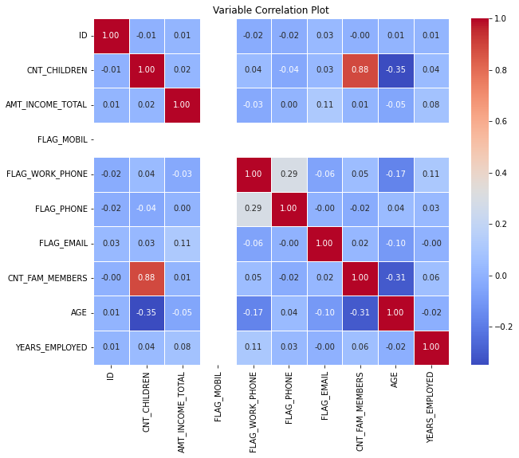

```python
application_corr_matrix = application_clean.corr()
plt.figure(figsize = (10,8))
sns.heatmap(application_corr_matrix, annot=True, cmap='coolwarm', fmt=".2f", linewidths=0.5)
plt.title('Variable Correlation Plot')
plt.show()
#not very surprised at the lack of correlation, most of these variables have nothing to do with each other
```

From the correlation matrix above, we can see that most of the variables have a very minimal degree of correlation which each other, which makes sense because the factors that credit card companies need to consider are vast and generally. unrelated to each other

Let's create bar plots of all the categorical variables in the application dataset so we can get an idea of what we're working with.

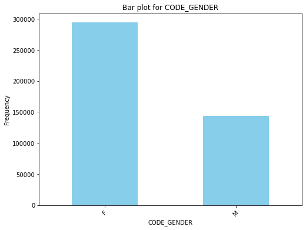

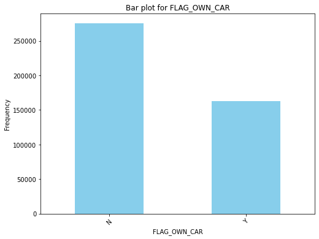

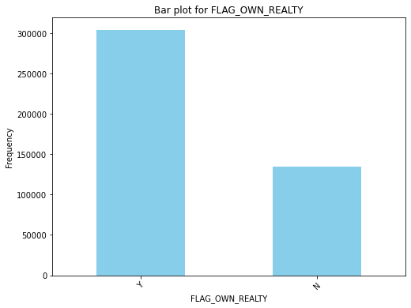

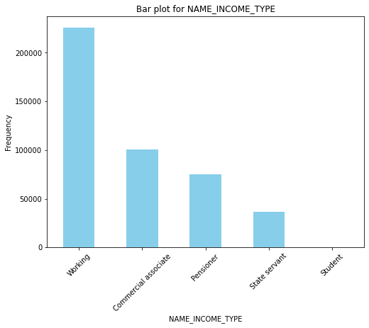

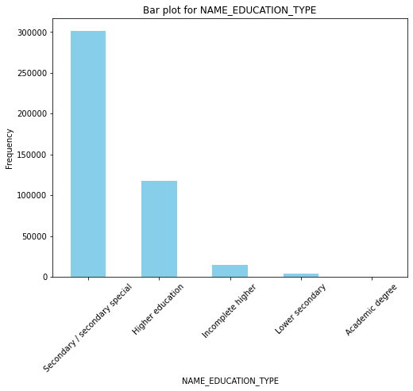

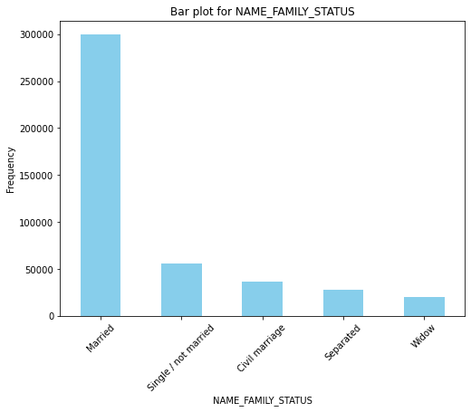

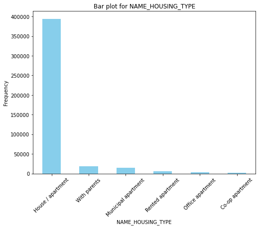

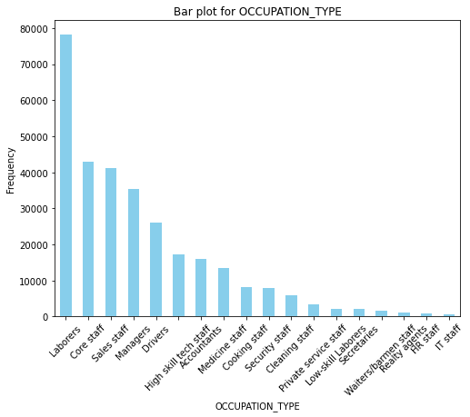

```python
def create_cat_graphs(df):
    cols = df.select_dtypes(include=['object']).columns
    for col in cols:
        plt.figure(figsize=(8, 6))
        df[col].value_counts().plot(kind='bar', color='skyblue')
        plt.title(f'Bar plot for {col}')
        plt.xlabel(col)
        plt.ylabel('Frequency')
        plt.xticks(rotation=45)
        plt.show()

create_cat_graphs(application_clean)
```

Now let's take a look at some of the binary (1/0) variables in this dataset.

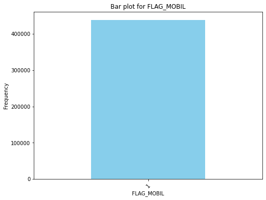

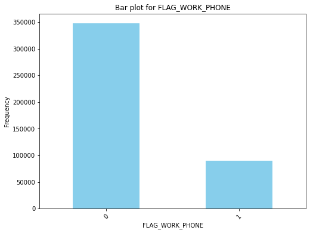

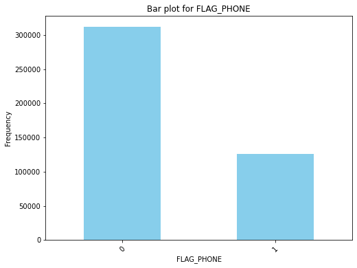

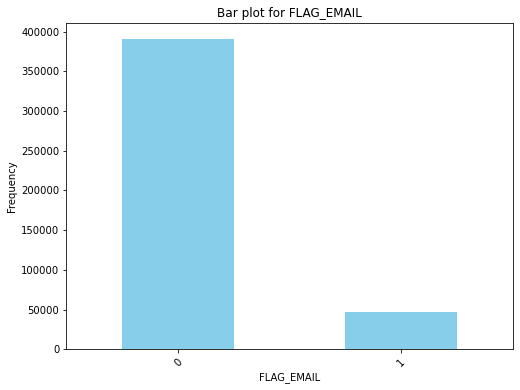

```python
cols = ['FLAG_MOBIL', 'FLAG_WORK_PHONE', 'FLAG_PHONE', 'FLAG_EMAIL']
for col in cols:
    plt.figure(figsize=(8, 6))
    application_clean[col].value_counts().plot(kind='bar', color='skyblue')
    plt.title(f'Bar plot for {col}')
    plt.xlabel(col)
    plt.ylabel('Frequency')
    plt.xticks(rotation=45)
    plt.show()
```

This is a nice place to switch gears to the credit dataset. As we will see, it is ultimately a more complex dataset because of the wrangling that I had to do to get it in a format that I liked.

## Credit Dataset

This will be more data wrangling than data cleaning.

```python
credit.dtypes
```

```
ID                 int64
MONTHS_BALANCE     int64
STATUS            object
dtype: object
```

```python
#new variables for credit csv can include duration, months on time per duration, ratio of on time months (C's) to duration,
#as well as for # of months late to duration, months where you actually had a balance (account for X)
#account for how late people are in days
credit_new = pd.DataFrame()
credit_new['DURATION'] = credit.groupby(['ID']).size()
credit_new.reset_index(inplace = True)
print(credit_new) #credit_new is simply to show us the duration of data we have per ID
```

```
            ID  DURATION
0      5001711         4
1      5001712        19
2      5001713        22
3      5001714        15
4      5001715        60
...        ...       ...
45980  5150482        18
45981  5150483        18
45982  5150484        13
45983  5150485         2
45984  5150487        30

[45985 rows x 2 columns]
```

```python
new_df = pd.DataFrame()
new_df['months'] = credit.groupby(['ID', 'STATUS']).size()
new_df.reset_index(inplace = True)
new_df2 = new_df.pivot_table(index='ID', columns='STATUS', values='months', fill_value = 0)
new_df2.reset_index(inplace = True)
print(new_df2) #new_df2 shows us the number of months on record per status as given in the credit dataset, which we will merge with credit_new
```

```
STATUS       ID   0  1  2  3  4  5   C   X
0       5001711   3  0  0  0  0  0   0   1
1       5001712  10  0  0  0  0  0   9   0
2       5001713   0  0  0  0  0  0   0  22
3       5001714   0  0  0  0  0  0   0  15
4       5001715   0  0  0  0  0  0   0  60
...         ...  .. .. .. .. .. ..  ..  ..
45980   5150482  12  0  0  0  0  0   6   0
45981   5150483   0  0  0  0  0  0   0  18
45982   5150484  12  0  0  0  0  0   1   0
45983   5150485   2  0  0  0  0  0   0   0
45984   5150487   0  0  0  0  0  0  30   0

[45985 rows x 9 columns]
```

What we have above looks pretty neat! We took the original credit data, grouped by ID and status, and made a pivot table to show for how long each person had each status (which will be useful later on). Let's now merge the dataframes.

```python
credit_final = credit_new.merge(new_df2, on = 'ID')
print(credit_final)
```

```
            ID  DURATION   0  1  2  3  4  5   C   X
0      5001711         4   3  0  0  0  0  0   0   1
1      5001712        19  10  0  0  0  0  0   9   0
2      5001713        22   0  0  0  0  0  0   0  22
3      5001714        15   0  0  0  0  0  0   0  15
4      5001715        60   0  0  0  0  0  0   0  60
...        ...       ...  .. .. .. .. .. ..  ..  ..
45980  5150482        18  12  0  0  0  0  0   6   0
45981  5150483        18   0  0  0  0  0  0   0  18
45982  5150484        13  12  0  0  0  0  0   1   0
45983  5150485         2   2  0  0  0  0  0   0   0
45984  5150487        30   0  0  0  0  0  0  30   0

[45985 rows x 10 columns]
```

On average, how long have people had their accounts open for?

```python
print(np.mean(credit_final['DURATION']))
```

```
22.802544307926496
```

On average, people have had their accounts open for almost 23 months. Now I want to look at how many months people have had balance on their cards, and I will do this by creating ratios of all the statuses.

```python
cols = ['0', '1', '2', '3', '4', '5', 'C', 'X']
for col in cols:
    credit_final[col] = credit_final[col] / credit_final['DURATION']
credit_final['MONTHS_WITH_BALANCE'] = credit_final['DURATION']*(1 - credit_final['X'])
print(credit_final)
```

```
            ID  DURATION         0    1    2    3    4    5         C     X  \
0      5001711         4  0.750000  0.0  0.0  0.0  0.0  0.0  0.000000  0.25
1      5001712        19  0.526316  0.0  0.0  0.0  0.0  0.0  0.473684  0.00
2      5001713        22  0.000000  0.0  0.0  0.0  0.0  0.0  0.000000  1.00
3      5001714        15  0.000000  0.0  0.0  0.0  0.0  0.0  0.000000  1.00
4      5001715        60  0.000000  0.0  0.0  0.0  0.0  0.0  0.000000  1.00
...        ...       ...       ...  ...  ...  ...  ...  ...       ...   ...
45980  5150482        18  0.666667  0.0  0.0  0.0  0.0  0.0  0.333333  0.00
45981  5150483        18  0.000000  0.0  0.0  0.0  0.0  0.0  0.000000  1.00
45982  5150484        13  0.923077  0.0  0.0  0.0  0.0  0.0  0.076923  0.00
45983  5150485         2  1.000000  0.0  0.0  0.0  0.0  0.0  0.000000  0.00
45984  5150487        30  0.000000  0.0  0.0  0.0  0.0  0.0  1.000000  0.00

       MONTHS_WITH_BALANCE
0                      3.0
1                     19.0
2                      0.0
3                      0.0
4                      0.0
...                    ...
45980                 18.0
45981                  0.0
45982                 13.0
45983                  2.0
45984                 30.0

[45985 rows x 11 columns]
```

When initially doing the coding portion, I realized that some of my values for `MONTHS_WITH_BALANCE` had slight decimal values, so I will now take time to ensure rounding.

```python
credit_final['MONTHS_WITH_BALANCE'] = np.round(credit_final['MONTHS_WITH_BALANCE'])
```

People with an 'X' ratio of 1 haven't used their card at all, and we might not want to consider them as a part of the final evaluation. But how many people don't have a balance?

```python
print(len(credit_final[credit_final['X'] == 1])) #4536 customers got the card but never used it
```

```
4536
```

4,536 people have received a card but not used it at all.

Let's now look at some delinquency data. For the sake of simplicity and for later use, I will separate out the users by how late they've been in English terms. The three different classes I will be creating are as follows: late by 90+ days, late by 30 to 90 days, and late from 1 to 29 days.

```python
#what % of people have had months where they carry a 90+ day overdue balance (classified by 3, 4, 5)
credit_final['90+ days'] = credit_final['3'] + credit_final['4'] + credit_final['5']
print(credit_final)
print(len(credit_final[credit_final['90+ days'] > 0])) #331 people over 90 days late
```

```
            ID  DURATION         0    1    2    3    4    5         C     X  \
0      5001711         4  0.750000  0.0  0.0  0.0  0.0  0.0  0.000000  0.25
1      5001712        19  0.526316  0.0  0.0  0.0  0.0  0.0  0.473684  0.00
2      5001713        22  0.000000  0.0  0.0  0.0  0.0  0.0  0.000000  1.00
3      5001714        15  0.000000  0.0  0.0  0.0  0.0  0.0  0.000000  1.00
4      5001715        60  0.000000  0.0  0.0  0.0  0.0  0.0  0.000000  1.00
...        ...       ...       ...  ...  ...  ...  ...  ...       ...   ...
45980  5150482        18  0.666667  0.0  0.0  0.0  0.0  0.0  0.333333  0.00
45981  5150483        18  0.000000  0.0  0.0  0.0  0.0  0.0  0.000000  1.00
45982  5150484        13  0.923077  0.0  0.0  0.0  0.0  0.0  0.076923  0.00
45983  5150485         2  1.000000  0.0  0.0  0.0  0.0  0.0  0.000000  0.00
45984  5150487        30  0.000000  0.0  0.0  0.0  0.0  0.0  1.000000  0.00

       MONTHS_WITH_BALANCE  90+ days
0                      3.0       0.0
1                     19.0       0.0
2                      0.0       0.0
3                      0.0       0.0
4                      0.0       0.0
...                    ...       ...
45980                 18.0       0.0
45981                  0.0       0.0
45982                 13.0       0.0
45983                  2.0       0.0
45984                 30.0       0.0

[45985 rows x 12 columns]
331
```

```python
credit_final['30 to 90 days'] = credit_final['1'] + credit_final['2']
print(credit_final)
print(len(credit_final[credit_final['30 to 90 days'] > 0])) #5295 people
```

```
            ID  DURATION         0    1    2    3    4    5         C     X  \
0      5001711         4  0.750000  0.0  0.0  0.0  0.0  0.0  0.000000  0.25
1      5001712        19  0.526316  0.0  0.0  0.0  0.0  0.0  0.473684  0.00
2      5001713        22  0.000000  0.0  0.0  0.0  0.0  0.0  0.000000  1.00
3      5001714        15  0.000000  0.0  0.0  0.0  0.0  0.0  0.000000  1.00
4      5001715        60  0.000000  0.0  0.0  0.0  0.0  0.0  0.000000  1.00
...        ...       ...       ...  ...  ...  ...  ...  ...       ...   ...
45980  5150482        18  0.666667  0.0  0.0  0.0  0.0  0.0  0.333333  0.00
45981  5150483        18  0.000000  0.0  0.0  0.0  0.0  0.0  0.000000  1.00
45982  5150484        13  0.923077  0.0  0.0  0.0  0.0  0.0  0.076923  0.00
45983  5150485         2  1.000000  0.0  0.0  0.0  0.0  0.0  0.000000  0.00
45984  5150487        30  0.000000  0.0  0.0  0.0  0.0  0.0  1.000000  0.00

       MONTHS_WITH_BALANCE  90+ days  30 to 90 days
0                      3.0       0.0            0.0
1                     19.0       0.0            0.0
2                      0.0       0.0            0.0
3                      0.0       0.0            0.0
4                      0.0       0.0            0.0
...                    ...       ...            ...
45980                 18.0       0.0            0.0
45981                  0.0       0.0            0.0
45982                 13.0       0.0            0.0
45983                  2.0       0.0            0.0
45984                 30.0       0.0            0.0

[45985 rows x 13 columns]
5295
```

```python
credit_final['1 to 29 days'] = credit_final['0']
print(credit_final)
print(len(credit_final[credit_final['1 to 29 days'] > 0])) #39,980 people out of 45,985 have some slight delinquency
```

```
            ID  DURATION         0    1    2    3    4    5         C     X  \
0      5001711         4  0.750000  0.0  0.0  0.0  0.0  0.0  0.000000  0.25
1      5001712        19  0.526316  0.0  0.0  0.0  0.0  0.0  0.473684  0.00
2      5001713        22  0.000000  0.0  0.0  0.0  0.0  0.0  0.000000  1.00
3      5001714        15  0.000000  0.0  0.0  0.0  0.0  0.0  0.000000  1.00
4      5001715        60  0.000000  0.0  0.0  0.0  0.0  0.0  0.000000  1.00
...        ...       ...       ...  ...  ...  ...  ...  ...       ...   ...
45980  5150482        18  0.666667  0.0  0.0  0.0  0.0  0.0  0.333333  0.00
45981  5150483        18  0.000000  0.0  0.0  0.0  0.0  0.0  0.000000  1.00
45982  5150484        13  0.923077  0.0  0.0  0.0  0.0  0.0  0.076923  0.00
45983  5150485         2  1.000000  0.0  0.0  0.0  0.0  0.0  0.000000  0.00
45984  5150487        30  0.000000  0.0  0.0  0.0  0.0  0.0  1.000000  0.00

       MONTHS_WITH_BALANCE  90+ days  30 to 90 days  1 to 29 days
0                      3.0       0.0            0.0      0.750000
1                     19.0       0.0            0.0      0.526316
2                      0.0       0.0            0.0      0.000000
3                      0.0       0.0            0.0      0.000000
4                      0.0       0.0            0.0      0.000000
...                    ...       ...            ...           ...
45980                 18.0       0.0            0.0      0.666667
45981                  0.0       0.0            0.0      0.000000
45982                 13.0       0.0            0.0      0.923077
45983                  2.0       0.0            0.0      1.000000
45984                 30.0       0.0            0.0      0.000000

[45985 rows x 14 columns]
39980
```

Now that the data is more simplified and some of the variables are put in easier terms to understand, I will take a look at some stats on the variable `MONTHS_WITH_BALANCE` to observe the distribution.

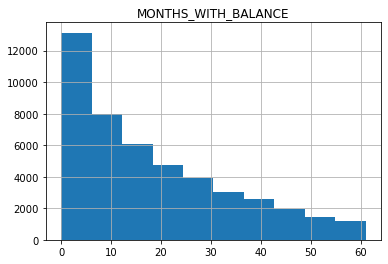

```
61.0
0.0
18.252582363814287
14.0
15.620461245478129
```

```python
months_plot = credit_final.hist(column = 'MONTHS_WITH_BALANCE', bins = 10)
plt.show(months_plot)
print(max(credit_final['MONTHS_WITH_BALANCE']))
print(min(credit_final['MONTHS_WITH_BALANCE']))
print(np.mean(credit_final['MONTHS_WITH_BALANCE']))
print(np.median(credit_final['MONTHS_WITH_BALANCE']))
print(np.std(credit_final['MONTHS_WITH_BALANCE']))
```

As we can see from the histogram above, there is a clear right skew with a lot of variance in the data. On average, people used their credit card for 18 months, with a median value of 14 months.

Now that we have a credit dataframe of all the status ratios and balance, we are ready to merge it with our cleaned application dataframe.

```python
#make sure there's a match between the credit df and application record
merged_df = credit_final.merge(application_clean, on = 'ID', how = 'inner')
print(merged_df) #36457 records
```

```
            ID  DURATION         0         1    2    3    4    5         C  \
0      5008804        16  0.062500  0.062500  0.0  0.0  0.0  0.0  0.812500
1      5008805        15  0.066667  0.066667  0.0  0.0  0.0  0.0  0.800000
2      5008806        30  0.233333  0.000000  0.0  0.0  0.0  0.0  0.233333
3      5008808         5  0.400000  0.000000  0.0  0.0  0.0  0.0  0.000000
4      5008809         5  0.000000  0.000000  0.0  0.0  0.0  0.0  0.000000
...        ...       ...       ...       ...  ...  ...  ...  ...       ...
36452  5150482        18  0.666667  0.000000  0.0  0.0  0.0  0.0  0.333333
36453  5150483        18  0.000000  0.000000  0.0  0.0  0.0  0.0  0.000000
36454  5150484        13  0.923077  0.000000  0.0  0.0  0.0  0.0  0.076923
36455  5150485         2  1.000000  0.000000  0.0  0.0  0.0  0.0  0.000000
36456  5150487        30  0.000000  0.000000  0.0  0.0  0.0  0.0  1.000000

              X  ...    NAME_FAMILY_STATUS  NAME_HOUSING_TYPE  FLAG_MOBIL  \
0      0.062500  ...        Civil marriage   Rented apartment           1
```

[output cut: 38 more lines]

We now have a merged dataframe of all the cleaned application data and credit data. It's now time to use this dataframe towards our final dataframe that we will use for model training.

## Dummify and Scale Explanatory Variables

Dummification takes all unique observations within a categorical variable and splits them up into their own variable, which then gets denoted with binary (1/0) notation. For a variable with k different observations, k-1 dummy variables will be created. For example, if we had a variable called "Color", with the observations being "Red", "Green", "Blue", and "Yellow", this variable would be dummy coded by created variables within the dataframe called "Color_Red", "Color_Green", and "Color_Blue". If the original color was Red, Color_Red would be marked as 1, with the other two marked as 0, and this would be the case for Green and Blue as well. However, if every entry for the newly created dummy variables is 0, that means the color variable value was Yellow.

The variables that get scaled are continuous explanatory variables. These do not include binary variables because those are denoted by either 1 or 0. Variables such as income, age, years employed will get scaled and we do this so that they can be compared to their means and standard deviations. The scaler we will use will return the z-score of each variable, and we will be able to understand how each entry is scaled relative to others.

### Missing Data?

Before scaling and dummifying, we must make sure we don't have any missing data. When I looked through the datasets, neither the credit nor application dataframes have missing data for the ID variable, which is good. However, some of the categorical variables seem to have missing data, so let's address this.

```python
#starting to dummify variables, import appropriate libraries
from sklearn.preprocessing import StandardScaler, OneHotEncoder
```

```python
cols = ['NAME_INCOME_TYPE', 'NAME_EDUCATION_TYPE', 'NAME_FAMILY_STATUS', 'NAME_HOUSING_TYPE', 'OCCUPATION_TYPE']
for col in cols:
    merged_df[col].fillna('not_specified', inplace = True)
    print(merged_df[col].value_counts(dropna = False))
```

```
Working                 18819
Commercial associate     8490
Pensioner                6152
State servant            2985
Student                    11
Name: NAME_INCOME_TYPE, dtype: int64
Secondary / secondary special    24777
Higher education                  9864
Incomplete higher                 1410
Lower secondary                    374
Academic degree                     32
Name: NAME_EDUCATION_TYPE, dtype: int64
Married                 25048
Single / not married     4829
Civil marriage           2945
Separated                2103
Widow                    1532
Name: NAME_FAMILY_STATUS, dtype: int64
House / apartment      32548
With parents            1776
Municipal apartment     1128
Rented apartment         575
Office apartment         262
Co-op apartment          168
Name: NAME_HOUSING_TYPE, dtype: int64
not_specified            11323
Laborers                  6211
Core staff                3591
Sales staff               3485
Managers                  3012
Drivers                   2138
High skill tech staff     1383
Accountants               1241
Medicine staff            1207
Cooking staff              655
Security staff             592
Cleaning staff             551
Private service staff      344
Low-skill Laborers         175
Waiters/barmen staff       174
Secretaries                151
HR staff                    85
Realty agents               79
IT staff                    60
Name: OCCUPATION_TYPE, dtype: int64
```

```python
#dummify variables using drop_first
columns_to_dummy = ['CODE_GENDER','FLAG_OWN_CAR','FLAG_OWN_REALTY', 'NAME_EDUCATION_TYPE','NAME_INCOME_TYPE', 'NAME_FAMILY_STATUS', 'NAME_HOUSING_TYPE',
                    'FLAG_WORK_PHONE', 'FLAG_PHONE', 'FLAG_EMAIL', 'OCCUPATION_TYPE']
merged_df = pd.get_dummies(merged_df, columns = columns_to_dummy, dtype = 'int', drop_first = True)
```

```python
merged_df
```

|  | ID | DURATION | 0 | 1 | 2 | 3 | 4 | 5 | C | X | ... | OCCUPATION_TYPE_Low-skill Laborers | OCCUPATION_TYPE_Managers | OCCUPATION_TYPE_Medicine staff | OCCUPATION_TYPE_Private service staff | OCCUPATION_TYPE_Realty agents | OCCUPATION_TYPE_Sales staff | OCCUPATION_TYPE_Secretaries | OCCUPATION_TYPE_Security staff | OCCUPATION_TYPE_Waiters/barmen staff | OCCUPATION_TYPE_not_specified |
| --- | --- | --- | --- | --- | --- | --- | --- | --- | --- | --- | --- | --- | --- | --- | --- | --- | --- | --- | --- | --- | --- |
| 0 | 5008804 | 16 | 0.062500 | 0.062500 | 0.0 | 0.0 | 0.0 | 0.0 | 0.812500 | 0.062500 | ... | 0 | 0 | 0 | 0 | 0 | 0 | 0 | 0 | 0 | 1 |
| 1 | 5008805 | 15 | 0.066667 | 0.066667 | 0.0 | 0.0 | 0.0 | 0.0 | 0.800000 | 0.066667 | ... | 0 | 0 | 0 | 0 | 0 | 0 | 0 | 0 | 0 | 1 |
| 2 | 5008806 | 30 | 0.233333 | 0.000000 | 0.0 | 0.0 | 0.0 | 0.0 | 0.233333 | 0.533333 | ... | 0 | 0 | 0 | 0 | 0 | 0 | 0 | 1 | 0 | 0 |
| 3 | 5008808 | 5 | 0.400000 | 0.000000 | 0.0 | 0.0 | 0.0 | 0.0 | 0.000000 | 0.600000 | ... | 0 | 0 | 0 | 0 | 0 | 1 | 0 | 0 | 0 | 0 |
| 4 | 5008809 | 5 | 0.000000 | 0.000000 | 0.0 | 0.0 | 0.0 | 0.0 | 0.000000 | 1.000000 | ... | 0 | 0 | 0 | 0 | 0 | 1 | 0 | 0 | 0 | 0 |
| ... | ... | ... | ... | ... | ... | ... | ... | ... | ... | ... | ... | ... | ... | ... | ... | ... | ... | ... | ... | ... | ... |
| 36452 | 5150482 | 18 | 0.666667 | 0.000000 | 0.0 | 0.0 | 0.0 | 0.0 | 0.333333 | 0.000000 | ... | 0 | 0 | 0 | 0 | 0 | 0 | 0 | 0 | 0 | 0 |
| 36453 | 5150483 | 18 | 0.000000 | 0.000000 | 0.0 | 0.0 | 0.0 | 0.0 | 0.000000 | 1.000000 | ... | 0 | 0 | 0 | 0 | 0 | 0 | 0 | 0 | 0 | 0 |
| 36454 | 5150484 | 13 | 0.923077 | 0.000000 | 0.0 | 0.0 | 0.0 | 0.0 | 0.076923 | 0.000000 | ... | 0 | 0 | 0 | 0 | 0 | 0 | 0 | 0 | 0 | 0 |
| 36455 | 5150485 | 2 | 1.000000 | 0.000000 | 0.0 | 0.0 | 0.0 | 0.0 | 0.000000 | 0.000000 | ... | 0 | 0 | 0 | 0 | 0 | 0 | 0 | 0 | 0 | 0 |
| 36456 | 5150487 | 30 | 0.000000 | 0.000000 | 0.0 | 0.0 | 0.0 | 0.0 | 1.000000 | 0.000000 | ... | 0 | 0 | 0 | 0 | 0 | 0 | 0 | 0 | 0 | 0 |

36457 rows × 61 columns

```python
#lets now scale the continuous variables we have in this dataset
columns_to_scale = ['CNT_CHILDREN','AMT_INCOME_TOTAL', 'AGE','YEARS_EMPLOYED', 'CNT_FAM_MEMBERS']
st = StandardScaler()
merged_df[columns_to_scale] = st.fit_transform(merged_df[columns_to_scale])
merged_df
```

|  | ID | DURATION | 0 | 1 | 2 | 3 | 4 | 5 | C | X | ... | OCCUPATION_TYPE_Low-skill Laborers | OCCUPATION_TYPE_Managers | OCCUPATION_TYPE_Medicine staff | OCCUPATION_TYPE_Private service staff | OCCUPATION_TYPE_Realty agents | OCCUPATION_TYPE_Sales staff | OCCUPATION_TYPE_Secretaries | OCCUPATION_TYPE_Security staff | OCCUPATION_TYPE_Waiters/barmen staff | OCCUPATION_TYPE_not_specified |
| --- | --- | --- | --- | --- | --- | --- | --- | --- | --- | --- | --- | --- | --- | --- | --- | --- | --- | --- | --- | --- | --- |
| 0 | 5008804 | 16 | 0.062500 | 0.062500 | 0.0 | 0.0 | 0.0 | 0.0 | 0.812500 | 0.062500 | ... | 0 | 0 | 0 | 0 | 0 | 0 | 0 | 0 | 0 | 1 |
| 1 | 5008805 | 15 | 0.066667 | 0.066667 | 0.0 | 0.0 | 0.0 | 0.0 | 0.800000 | 0.066667 | ... | 0 | 0 | 0 | 0 | 0 | 0 | 0 | 0 | 0 | 1 |
| 2 | 5008806 | 30 | 0.233333 | 0.000000 | 0.0 | 0.0 | 0.0 | 0.0 | 0.233333 | 0.533333 | ... | 0 | 0 | 0 | 0 | 0 | 0 | 0 | 1 | 0 | 0 |
| 3 | 5008808 | 5 | 0.400000 | 0.000000 | 0.0 | 0.0 | 0.0 | 0.0 | 0.000000 | 0.600000 | ... | 0 | 0 | 0 | 0 | 0 | 1 | 0 | 0 | 0 | 0 |
| 4 | 5008809 | 5 | 0.000000 | 0.000000 | 0.0 | 0.0 | 0.0 | 0.0 | 0.000000 | 1.000000 | ... | 0 | 0 | 0 | 0 | 0 | 1 | 0 | 0 | 0 | 0 |
| ... | ... | ... | ... | ... | ... | ... | ... | ... | ... | ... | ... | ... | ... | ... | ... | ... | ... | ... | ... | ... | ... |
| 36452 | 5150482 | 18 | 0.666667 | 0.000000 | 0.0 | 0.0 | 0.0 | 0.0 | 0.333333 | 0.000000 | ... | 0 | 0 | 0 | 0 | 0 | 0 | 0 | 0 | 0 | 0 |
| 36453 | 5150483 | 18 | 0.000000 | 0.000000 | 0.0 | 0.0 | 0.0 | 0.0 | 0.000000 | 1.000000 | ... | 0 | 0 | 0 | 0 | 0 | 0 | 0 | 0 | 0 | 0 |
| 36454 | 5150484 | 13 | 0.923077 | 0.000000 | 0.0 | 0.0 | 0.0 | 0.0 | 0.076923 | 0.000000 | ... | 0 | 0 | 0 | 0 | 0 | 0 | 0 | 0 | 0 | 0 |
| 36455 | 5150485 | 2 | 1.000000 | 0.000000 | 0.0 | 0.0 | 0.0 | 0.0 | 0.000000 | 0.000000 | ... | 0 | 0 | 0 | 0 | 0 | 0 | 0 | 0 | 0 | 0 |
| 36456 | 5150487 | 30 | 0.000000 | 0.000000 | 0.0 | 0.0 | 0.0 | 0.0 | 1.000000 | 0.000000 | ... | 0 | 0 | 0 | 0 | 0 | 0 | 0 | 0 | 0 | 0 |

36457 rows × 61 columns

As we can see, dummifyng our categorical variables took us from 31 columns to 61 columns. This will make it easier for our machine learning models to use these variables when running.

However, we aren't quite done. We still need to create our outcome variable, and that will be done in the code below.

## Outcome Variable and Its Criteria

For my outcome variable, I will set people who have a combined ratio of 1-29 days late, 30-59 days late, and on time payments of at least 80% to good candidates (0), and the rest to bad candidates (1). I will created an intermediate variable `ON_TIME_TO_60_LATE` to make this easier.

```python
merged_df['ON_TIME_TO_60_LATE'] = merged_df['0'] + merged_df['1'] + merged_df['C']
```

```python
merged_df
```

|  | ID | DURATION | 0 | 1 | 2 | 3 | 4 | 5 | C | X | ... | OCCUPATION_TYPE_Managers | OCCUPATION_TYPE_Medicine staff | OCCUPATION_TYPE_Private service staff | OCCUPATION_TYPE_Realty agents | OCCUPATION_TYPE_Sales staff | OCCUPATION_TYPE_Secretaries | OCCUPATION_TYPE_Security staff | OCCUPATION_TYPE_Waiters/barmen staff | OCCUPATION_TYPE_not_specified | ON_TIME_TO_60_LATE |
| --- | --- | --- | --- | --- | --- | --- | --- | --- | --- | --- | --- | --- | --- | --- | --- | --- | --- | --- | --- | --- | --- |
| 0 | 5008804 | 16 | 0.062500 | 0.062500 | 0.0 | 0.0 | 0.0 | 0.0 | 0.812500 | 0.062500 | ... | 0 | 0 | 0 | 0 | 0 | 0 | 0 | 0 | 1 | 0.937500 |
| 1 | 5008805 | 15 | 0.066667 | 0.066667 | 0.0 | 0.0 | 0.0 | 0.0 | 0.800000 | 0.066667 | ... | 0 | 0 | 0 | 0 | 0 | 0 | 0 | 0 | 1 | 0.933333 |
| 2 | 5008806 | 30 | 0.233333 | 0.000000 | 0.0 | 0.0 | 0.0 | 0.0 | 0.233333 | 0.533333 | ... | 0 | 0 | 0 | 0 | 0 | 0 | 1 | 0 | 0 | 0.466667 |
| 3 | 5008808 | 5 | 0.400000 | 0.000000 | 0.0 | 0.0 | 0.0 | 0.0 | 0.000000 | 0.600000 | ... | 0 | 0 | 0 | 0 | 1 | 0 | 0 | 0 | 0 | 0.400000 |
| 4 | 5008809 | 5 | 0.000000 | 0.000000 | 0.0 | 0.0 | 0.0 | 0.0 | 0.000000 | 1.000000 | ... | 0 | 0 | 0 | 0 | 1 | 0 | 0 | 0 | 0 | 0.000000 |
| ... | ... | ... | ... | ... | ... | ... | ... | ... | ... | ... | ... | ... | ... | ... | ... | ... | ... | ... | ... | ... | ... |
| 36452 | 5150482 | 18 | 0.666667 | 0.000000 | 0.0 | 0.0 | 0.0 | 0.0 | 0.333333 | 0.000000 | ... | 0 | 0 | 0 | 0 | 0 | 0 | 0 | 0 | 0 | 1.000000 |
| 36453 | 5150483 | 18 | 0.000000 | 0.000000 | 0.0 | 0.0 | 0.0 | 0.0 | 0.000000 | 1.000000 | ... | 0 | 0 | 0 | 0 | 0 | 0 | 0 | 0 | 0 | 0.000000 |
| 36454 | 5150484 | 13 | 0.923077 | 0.000000 | 0.0 | 0.0 | 0.0 | 0.0 | 0.076923 | 0.000000 | ... | 0 | 0 | 0 | 0 | 0 | 0 | 0 | 0 | 0 | 1.000000 |
| 36455 | 5150485 | 2 | 1.000000 | 0.000000 | 0.0 | 0.0 | 0.0 | 0.0 | 0.000000 | 0.000000 | ... | 0 | 0 | 0 | 0 | 0 | 0 | 0 | 0 | 0 | 1.000000 |
| 36456 | 5150487 | 30 | 0.000000 | 0.000000 | 0.0 | 0.0 | 0.0 | 0.0 | 1.000000 | 0.000000 | ... | 0 | 0 | 0 | 0 | 0 | 0 | 0 | 0 | 0 | 1.000000 |

36457 rows × 62 columns

```python
#set our good/bad condition, goods are set to 0 and bads set to 1
merged_df['GOOD_BAD'] = np.where((merged_df['ON_TIME_TO_60_LATE'] >= 0.8), 0, 1)
merged_df
```

|  | ID | DURATION | 0 | 1 | 2 | 3 | 4 | 5 | C | X | ... | OCCUPATION_TYPE_Medicine staff | OCCUPATION_TYPE_Private service staff | OCCUPATION_TYPE_Realty agents | OCCUPATION_TYPE_Sales staff | OCCUPATION_TYPE_Secretaries | OCCUPATION_TYPE_Security staff | OCCUPATION_TYPE_Waiters/barmen staff | OCCUPATION_TYPE_not_specified | ON_TIME_TO_60_LATE | GOOD_BAD |
| --- | --- | --- | --- | --- | --- | --- | --- | --- | --- | --- | --- | --- | --- | --- | --- | --- | --- | --- | --- | --- | --- |
| 0 | 5008804 | 16 | 0.062500 | 0.062500 | 0.0 | 0.0 | 0.0 | 0.0 | 0.812500 | 0.062500 | ... | 0 | 0 | 0 | 0 | 0 | 0 | 0 | 1 | 0.937500 | 0 |
| 1 | 5008805 | 15 | 0.066667 | 0.066667 | 0.0 | 0.0 | 0.0 | 0.0 | 0.800000 | 0.066667 | ... | 0 | 0 | 0 | 0 | 0 | 0 | 0 | 1 | 0.933333 | 0 |
| 2 | 5008806 | 30 | 0.233333 | 0.000000 | 0.0 | 0.0 | 0.0 | 0.0 | 0.233333 | 0.533333 | ... | 0 | 0 | 0 | 0 | 0 | 1 | 0 | 0 | 0.466667 | 1 |
| 3 | 5008808 | 5 | 0.400000 | 0.000000 | 0.0 | 0.0 | 0.0 | 0.0 | 0.000000 | 0.600000 | ... | 0 | 0 | 0 | 1 | 0 | 0 | 0 | 0 | 0.400000 | 1 |
| 4 | 5008809 | 5 | 0.000000 | 0.000000 | 0.0 | 0.0 | 0.0 | 0.0 | 0.000000 | 1.000000 | ... | 0 | 0 | 0 | 1 | 0 | 0 | 0 | 0 | 0.000000 | 1 |
| ... | ... | ... | ... | ... | ... | ... | ... | ... | ... | ... | ... | ... | ... | ... | ... | ... | ... | ... | ... | ... | ... |
| 36452 | 5150482 | 18 | 0.666667 | 0.000000 | 0.0 | 0.0 | 0.0 | 0.0 | 0.333333 | 0.000000 | ... | 0 | 0 | 0 | 0 | 0 | 0 | 0 | 0 | 1.000000 | 0 |
| 36453 | 5150483 | 18 | 0.000000 | 0.000000 | 0.0 | 0.0 | 0.0 | 0.0 | 0.000000 | 1.000000 | ... | 0 | 0 | 0 | 0 | 0 | 0 | 0 | 0 | 0.000000 | 1 |
| 36454 | 5150484 | 13 | 0.923077 | 0.000000 | 0.0 | 0.0 | 0.0 | 0.0 | 0.076923 | 0.000000 | ... | 0 | 0 | 0 | 0 | 0 | 0 | 0 | 0 | 1.000000 | 0 |
| 36455 | 5150485 | 2 | 1.000000 | 0.000000 | 0.0 | 0.0 | 0.0 | 0.0 | 0.000000 | 0.000000 | ... | 0 | 0 | 0 | 0 | 0 | 0 | 0 | 0 | 1.000000 | 0 |
| 36456 | 5150487 | 30 | 0.000000 | 0.000000 | 0.0 | 0.0 | 0.0 | 0.0 | 1.000000 | 0.000000 | ... | 0 | 0 | 0 | 0 | 0 | 0 | 0 | 0 | 1.000000 | 0 |

36457 rows × 63 columns

Now that the outcome variable has been created, let's take a look at the distribution of goods and bads in this dataframe.

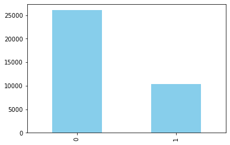

```python
#lets take a second to look at the counts of good/bad. this will inform how balanced our data is
merged_df['GOOD_BAD'].value_counts().plot(kind='bar', color='skyblue')
plt.show()
```

# Finalizing Our Model Selection Dataset

Now that we have our outcome variable, we can filter the data even more to only consider people who have months with balance. I'm doing this because by excluding these people, we will only have people in the dataset who have used their credit card.

```python
print(len(merged_df[merged_df['MONTHS_WITH_BALANCE'] == 0]))
```

```
3347
```

```python
#we can ignore the 3347 people who don't have balance
people_with_balance = merged_df[merged_df['MONTHS_WITH_BALANCE'] != 0]
people_with_balance
```

|  | ID | DURATION | 0 | 1 | 2 | 3 | 4 | 5 | C | X | ... | OCCUPATION_TYPE_Medicine staff | OCCUPATION_TYPE_Private service staff | OCCUPATION_TYPE_Realty agents | OCCUPATION_TYPE_Sales staff | OCCUPATION_TYPE_Secretaries | OCCUPATION_TYPE_Security staff | OCCUPATION_TYPE_Waiters/barmen staff | OCCUPATION_TYPE_not_specified | ON_TIME_TO_60_LATE | GOOD_BAD |
| --- | --- | --- | --- | --- | --- | --- | --- | --- | --- | --- | --- | --- | --- | --- | --- | --- | --- | --- | --- | --- | --- |
| 0 | 5008804 | 16 | 0.062500 | 0.062500 | 0.0 | 0.0 | 0.0 | 0.0 | 0.812500 | 0.062500 | ... | 0 | 0 | 0 | 0 | 0 | 0 | 0 | 1 | 0.937500 | 0 |
| 1 | 5008805 | 15 | 0.066667 | 0.066667 | 0.0 | 0.0 | 0.0 | 0.0 | 0.800000 | 0.066667 | ... | 0 | 0 | 0 | 0 | 0 | 0 | 0 | 1 | 0.933333 | 0 |
| 2 | 5008806 | 30 | 0.233333 | 0.000000 | 0.0 | 0.0 | 0.0 | 0.0 | 0.233333 | 0.533333 | ... | 0 | 0 | 0 | 0 | 0 | 1 | 0 | 0 | 0.466667 | 1 |
| 3 | 5008808 | 5 | 0.400000 | 0.000000 | 0.0 | 0.0 | 0.0 | 0.0 | 0.000000 | 0.600000 | ... | 0 | 0 | 0 | 1 | 0 | 0 | 0 | 0 | 0.400000 | 1 |
| 5 | 5008810 | 27 | 0.222222 | 0.000000 | 0.0 | 0.0 | 0.0 | 0.0 | 0.555556 | 0.222222 | ... | 0 | 0 | 0 | 1 | 0 | 0 | 0 | 0 | 0.777778 | 1 |
| ... | ... | ... | ... | ... | ... | ... | ... | ... | ... | ... | ... | ... | ... | ... | ... | ... | ... | ... | ... | ... | ... |
| 36450 | 5150480 | 26 | 0.230769 | 0.000000 | 0.0 | 0.0 | 0.0 | 0.0 | 0.769231 | 0.000000 | ... | 0 | 0 | 0 | 0 | 0 | 0 | 0 | 0 | 1.000000 | 0 |
| 36452 | 5150482 | 18 | 0.666667 | 0.000000 | 0.0 | 0.0 | 0.0 | 0.0 | 0.333333 | 0.000000 | ... | 0 | 0 | 0 | 0 | 0 | 0 | 0 | 0 | 1.000000 | 0 |
| 36454 | 5150484 | 13 | 0.923077 | 0.000000 | 0.0 | 0.0 | 0.0 | 0.0 | 0.076923 | 0.000000 | ... | 0 | 0 | 0 | 0 | 0 | 0 | 0 | 0 | 1.000000 | 0 |
| 36455 | 5150485 | 2 | 1.000000 | 0.000000 | 0.0 | 0.0 | 0.0 | 0.0 | 0.000000 | 0.000000 | ... | 0 | 0 | 0 | 0 | 0 | 0 | 0 | 0 | 1.000000 | 0 |
| 36456 | 5150487 | 30 | 0.000000 | 0.000000 | 0.0 | 0.0 | 0.0 | 0.0 | 1.000000 | 0.000000 | ... | 0 | 0 | 0 | 0 | 0 | 0 | 0 | 0 | 1.000000 | 0 |

33110 rows × 63 columns

```python
#we didn't scale duration and months with balance earlier, let's do that
duration_scale = ['DURATION', 'MONTHS_WITH_BALANCE']
st = StandardScaler()
people_with_balance[duration_scale] = st.fit_transform(people_with_balance[duration_scale])
people_with_balance
```

|  | ID | DURATION | 0 | 1 | 2 | 3 | 4 | 5 | C | X | ... | OCCUPATION_TYPE_Medicine staff | OCCUPATION_TYPE_Private service staff | OCCUPATION_TYPE_Realty agents | OCCUPATION_TYPE_Sales staff | OCCUPATION_TYPE_Secretaries | OCCUPATION_TYPE_Security staff | OCCUPATION_TYPE_Waiters/barmen staff | OCCUPATION_TYPE_not_specified | ON_TIME_TO_60_LATE | GOOD_BAD |
| --- | --- | --- | --- | --- | --- | --- | --- | --- | --- | --- | --- | --- | --- | --- | --- | --- | --- | --- | --- | --- | --- |
| 0 | 5008804 | -0.366243 | 0.062500 | 0.062500 | 0.0 | 0.0 | 0.0 | 0.0 | 0.812500 | 0.062500 | ... | 0 | 0 | 0 | 0 | 0 | 0 | 0 | 1 | 0.937500 | 0 |
| 1 | 5008805 | -0.433216 | 0.066667 | 0.066667 | 0.0 | 0.0 | 0.0 | 0.0 | 0.800000 | 0.066667 | ... | 0 | 0 | 0 | 0 | 0 | 0 | 0 | 1 | 0.933333 | 0 |
| 2 | 5008806 | 0.571372 | 0.233333 | 0.000000 | 0.0 | 0.0 | 0.0 | 0.0 | 0.233333 | 0.533333 | ... | 0 | 0 | 0 | 0 | 0 | 1 | 0 | 0 | 0.466667 | 1 |
| 3 | 5008808 | -1.102941 | 0.400000 | 0.000000 | 0.0 | 0.0 | 0.0 | 0.0 | 0.000000 | 0.600000 | ... | 0 | 0 | 0 | 1 | 0 | 0 | 0 | 0 | 0.400000 | 1 |
| 5 | 5008810 | 0.370455 | 0.222222 | 0.000000 | 0.0 | 0.0 | 0.0 | 0.0 | 0.555556 | 0.222222 | ... | 0 | 0 | 0 | 1 | 0 | 0 | 0 | 0 | 0.777778 | 1 |
| ... | ... | ... | ... | ... | ... | ... | ... | ... | ... | ... | ... | ... | ... | ... | ... | ... | ... | ... | ... | ... | ... |
| 36450 | 5150480 | 0.303482 | 0.230769 | 0.000000 | 0.0 | 0.0 | 0.0 | 0.0 | 0.769231 | 0.000000 | ... | 0 | 0 | 0 | 0 | 0 | 0 | 0 | 0 | 1.000000 | 0 |
| 36452 | 5150482 | -0.232298 | 0.666667 | 0.000000 | 0.0 | 0.0 | 0.0 | 0.0 | 0.333333 | 0.000000 | ... | 0 | 0 | 0 | 0 | 0 | 0 | 0 | 0 | 1.000000 | 0 |
| 36454 | 5150484 | -0.567161 | 0.923077 | 0.000000 | 0.0 | 0.0 | 0.0 | 0.0 | 0.076923 | 0.000000 | ... | 0 | 0 | 0 | 0 | 0 | 0 | 0 | 0 | 1.000000 | 0 |
| 36455 | 5150485 | -1.303859 | 1.000000 | 0.000000 | 0.0 | 0.0 | 0.0 | 0.0 | 0.000000 | 0.000000 | ... | 0 | 0 | 0 | 0 | 0 | 0 | 0 | 0 | 1.000000 | 0 |
| 36456 | 5150487 | 0.571372 | 0.000000 | 0.000000 | 0.0 | 0.0 | 0.0 | 0.0 | 1.000000 | 0.000000 | ... | 0 | 0 | 0 | 0 | 0 | 0 | 0 | 0 | 1.000000 | 0 |

33110 rows × 63 columns

We are almost converging on our final dataset that we can use for modeling! I say almost because some columns, such as the status ratios, need to be deleted because they were directly used in formulas for determining the outcome variable and we want to avoid multicollinearity.

```python
people_final = people_with_balance.drop(columns = ['ID', '0', '1', '2', '3', '4', '5', 'C', 'X', '90+ days', '30 to 90 days', '1 to 29 days',
                            'FLAG_MOBIL', 'ON_TIME_TO_60_LATE'])
people_final
```

|  | DURATION | MONTHS_WITH_BALANCE | CNT_CHILDREN | AMT_INCOME_TOTAL | CNT_FAM_MEMBERS | AGE | YEARS_EMPLOYED | CODE_GENDER_M | FLAG_OWN_CAR_Y | FLAG_OWN_REALTY_Y | ... | OCCUPATION_TYPE_Managers | OCCUPATION_TYPE_Medicine staff | OCCUPATION_TYPE_Private service staff | OCCUPATION_TYPE_Realty agents | OCCUPATION_TYPE_Sales staff | OCCUPATION_TYPE_Secretaries | OCCUPATION_TYPE_Security staff | OCCUPATION_TYPE_Waiters/barmen staff | OCCUPATION_TYPE_not_specified | GOOD_BAD |
| --- | --- | --- | --- | --- | --- | --- | --- | --- | --- | --- | --- | --- | --- | --- | --- | --- | --- | --- | --- | --- | --- |
| 0 | -0.366243 | -0.279186 | -0.579661 | 2.365845 | -0.217680 | -0.945169 | 0.989403 | 1 | 1 | 1 | ... | 0 | 0 | 0 | 0 | 0 | 0 | 0 | 0 | 1 | 0 |
| 1 | -0.433216 | -0.347601 | -0.579661 | 2.365845 | -0.217680 | -0.945169 | 0.989403 | 1 | 1 | 1 | ... | 0 | 0 | 0 | 0 | 0 | 0 | 0 | 0 | 1 | 0 |
| 2 | 0.571372 | -0.347601 | -0.579661 | -0.728827 | -0.217680 | 1.309091 | -0.450538 | 1 | 1 | 1 | ... | 0 | 0 | 0 | 0 | 0 | 0 | 1 | 0 | 0 | 1 |
| 3 | -1.102941 | -1.168576 | -0.579661 | 0.818509 | -1.314564 | 0.746300 | 0.359429 | 0 | 0 | 1 | ... | 0 | 0 | 0 | 0 | 1 | 0 | 0 | 0 | 0 | 1 |
| 5 | 0.370455 | 0.131302 | -0.579661 | 0.818509 | -1.314564 | 0.746300 | 0.359429 | 0 | 0 | 1 | ... | 0 | 0 | 0 | 0 | 1 | 0 | 0 | 0 | 0 | 1 |
| ... | ... | ... | ... | ... | ... | ... | ... | ... | ... | ... | ... | ... | ... | ... | ... | ... | ... | ... | ... | ... | ... |
| 36450 | 0.303482 | 0.473375 | 0.767400 | -0.286731 | 0.879204 | -1.230135 | -0.194915 | 0 | 1 | 1 | ... | 0 | 0 | 0 | 0 | 0 | 0 | 0 | 0 | 0 | 0 |
| 36452 | -0.232298 | -0.073942 | 0.767400 | -0.286731 | 0.879204 | -1.230135 | -0.194915 | 0 | 1 | 1 | ... | 0 | 0 | 0 | 0 | 0 | 0 | 0 | 0 | 0 | 0 |
| 36454 | -0.567161 | -0.416015 | 0.767400 | -0.286731 | 0.879204 | -1.230135 | -0.194915 | 0 | 1 | 1 | ... | 0 | 0 | 0 | 0 | 0 | 0 | 0 | 0 | 0 | 0 |
| 36455 | -1.303859 | -1.168576 | 0.767400 | -0.286731 | 0.879204 | -1.230135 | -0.194915 | 0 | 1 | 1 | ... | 0 | 0 | 0 | 0 | 0 | 0 | 0 | 0 | 0 | 0 |
| 36456 | 0.571372 | 0.747034 | -0.579661 | 0.155365 | -0.217680 | 0.814863 | -0.014500 | 1 | 1 | 0 | ... | 0 | 0 | 0 | 0 | 0 | 0 | 0 | 0 | 0 | 0 |

33110 rows × 49 columns

```python
#months with balance is directly calculated from duration, and we intentionally chose those with a balance to look at.
#so, let's delete duration.
people_final = people_final.drop(columns = ['DURATION'])
people_final
```

|  | MONTHS_WITH_BALANCE | CNT_CHILDREN | AMT_INCOME_TOTAL | CNT_FAM_MEMBERS | AGE | YEARS_EMPLOYED | CODE_GENDER_M | FLAG_OWN_CAR_Y | FLAG_OWN_REALTY_Y | NAME_EDUCATION_TYPE_Higher education | ... | OCCUPATION_TYPE_Managers | OCCUPATION_TYPE_Medicine staff | OCCUPATION_TYPE_Private service staff | OCCUPATION_TYPE_Realty agents | OCCUPATION_TYPE_Sales staff | OCCUPATION_TYPE_Secretaries | OCCUPATION_TYPE_Security staff | OCCUPATION_TYPE_Waiters/barmen staff | OCCUPATION_TYPE_not_specified | GOOD_BAD |
| --- | --- | --- | --- | --- | --- | --- | --- | --- | --- | --- | --- | --- | --- | --- | --- | --- | --- | --- | --- | --- | --- |
| 0 | -0.279186 | -0.579661 | 2.365845 | -0.217680 | -0.945169 | 0.989403 | 1 | 1 | 1 | 1 | ... | 0 | 0 | 0 | 0 | 0 | 0 | 0 | 0 | 1 | 0 |
| 1 | -0.347601 | -0.579661 | 2.365845 | -0.217680 | -0.945169 | 0.989403 | 1 | 1 | 1 | 1 | ... | 0 | 0 | 0 | 0 | 0 | 0 | 0 | 0 | 1 | 0 |
| 2 | -0.347601 | -0.579661 | -0.728827 | -0.217680 | 1.309091 | -0.450538 | 1 | 1 | 1 | 0 | ... | 0 | 0 | 0 | 0 | 0 | 0 | 1 | 0 | 0 | 1 |
| 3 | -1.168576 | -0.579661 | 0.818509 | -1.314564 | 0.746300 | 0.359429 | 0 | 0 | 1 | 0 | ... | 0 | 0 | 0 | 0 | 1 | 0 | 0 | 0 | 0 | 1 |
| 5 | 0.131302 | -0.579661 | 0.818509 | -1.314564 | 0.746300 | 0.359429 | 0 | 0 | 1 | 0 | ... | 0 | 0 | 0 | 0 | 1 | 0 | 0 | 0 | 0 | 1 |
| ... | ... | ... | ... | ... | ... | ... | ... | ... | ... | ... | ... | ... | ... | ... | ... | ... | ... | ... | ... | ... | ... |
| 36450 | 0.473375 | 0.767400 | -0.286731 | 0.879204 | -1.230135 | -0.194915 | 0 | 1 | 1 | 0 | ... | 0 | 0 | 0 | 0 | 0 | 0 | 0 | 0 | 0 | 0 |
| 36452 | -0.073942 | 0.767400 | -0.286731 | 0.879204 | -1.230135 | -0.194915 | 0 | 1 | 1 | 0 | ... | 0 | 0 | 0 | 0 | 0 | 0 | 0 | 0 | 0 | 0 |
| 36454 | -0.416015 | 0.767400 | -0.286731 | 0.879204 | -1.230135 | -0.194915 | 0 | 1 | 1 | 0 | ... | 0 | 0 | 0 | 0 | 0 | 0 | 0 | 0 | 0 | 0 |
| 36455 | -1.168576 | 0.767400 | -0.286731 | 0.879204 | -1.230135 | -0.194915 | 0 | 1 | 1 | 0 | ... | 0 | 0 | 0 | 0 | 0 | 0 | 0 | 0 | 0 | 0 |
| 36456 | 0.747034 | -0.579661 | 0.155365 | -0.217680 | 0.814863 | -0.014500 | 1 | 1 | 0 | 0 | ... | 0 | 0 | 0 | 0 | 0 | 0 | 0 | 0 | 0 | 0 |

33110 rows × 48 columns

This is now the final dataset that we will use for our models and to split the data into training and testing. Without further ado, let's get straight into it.

# Feature Selection and Train/Test Split

In machine learning, we use a train/test split to evaluate the performance of a model. It's a standard practice to use at least 70% of data for training and the remaining data for testing. The training data is used to fit the model, and we use the testing data for predictions on new, unseen data. I will be using a 70/30 training/testing split. The purpose of doing this is to avoid overfitting, where we have a model that performs very well on given data but poorly on new data. We will stratify on our outcome variable, `GOOD_BAD`.

For all our models, the following process will be followed:

a) create predictions and illustrate through a classification table

b) oversampling data and creating new predictions, illustrating with a classification table

c) k-fold cross validation (using the original model fit)

d) hyperparameter tuning (for models that require)

e) k-fold cross validation on hyperparameter tuned models (for models that got tuned)

```python
x = people_final.drop(columns = ['GOOD_BAD'])
y = people_final['GOOD_BAD']
```

```python
#getting our testing and training data, stratify on prediction variable (y)
from sklearn.model_selection import train_test_split as split
import sklearn.metrics as metrics
x_train, x_test, y_train, y_test = split(x, y, test_size = 0.3, stratify = y, random_state = 42)
```

## Metric Evaluation

There are several ways to evaluate the performance of a classification model. Some common metrics include: ROC_AUC, Accuracy and Balanced Accuracy, Precision, Recall, F1 Score.

In our case, due to significant class imbalance, simple measures like accuracy will not work. But measures like Precision, Recall and F1 will.

A high recall (for “bads”) means that the model is able to correctly identifying most the “bads” in the population.

A high precision (for “bads”) means that when the model thinks that something is “bad”, it very likely is.

We want both. And a F1 Score, which is the harmonic mean of Recall and Precision, is a good way to measure this. For this reason, I’ve chosen to use the F1 Score as the primary metrics to evaluate model performance.

The models I've chosen to fit are Logistic Regression, Quadratic Discriminant Analysis, XGBoost, and Random Forest, and I will provide explanations for them in their respective sections.

# Logistic Regression Model

Logistic Regression models aim to predict the probability that an instance belongs to a certain class. In our class, that will be predicting, based on the predictor variables that we defined above, if a candidate is good (0) or bad (1).

```python
from sklearn.linear_model import LogisticRegression
from sklearn.metrics import f1_score, precision_score, confusion_matrix, classification_report, accuracy_score, recall_score
```

```python
logistic_model = LogisticRegression(max_iter = 2000).fit(x_train, y_train)
y_log_test_pred = logistic_model.predict(x_test)
y_log_train_pred = logistic_model.predict(x_train)
print("Training accuracy: ", accuracy_score(y_train, y_log_train_pred))
print("Testing accuracy: ", accuracy_score(y_test, y_log_test_pred))
log_test_report = classification_report(y_test, y_log_test_pred)
print(log_test_report)
f1_test_logistic = f1_score(y_test, y_log_test_pred, average = 'weighted')
print("F1 Score: ", f1_test_logistic)
precision_test_logistic = precision_score(y_test, y_log_test_pred, average = 'weighted')
print("Precision Score: ", precision_test_logistic)
```

```
Training accuracy:  0.8089053803339518
Testing accuracy:  0.8084163898117387
              precision    recall  f1-score   support

           0       0.81      0.98      0.89      7816
           1       0.72      0.17      0.27      2117

    accuracy                           0.81      9933
   macro avg       0.77      0.57      0.58      9933
weighted avg       0.79      0.81      0.76      9933

F1 Score:  0.7574450734230516
Precision Score:  0.7931799492044886
```

```python
#lets get these same statistics for the training data
log_train_report = classification_report(y_train, y_log_train_pred)
print(log_train_report)
f1_train_logistic = f1_score(y_train, y_log_train_pred, average = 'weighted')
print("F1 Score: ", f1_train_logistic)
precision_train_logistic = precision_score(y_train, y_log_train_pred, average = 'weighted')
print("Precision Score: ", precision_train_logistic)
```

```
              precision    recall  f1-score   support

           0       0.81      0.98      0.89     18237
           1       0.72      0.17      0.28      4940

    accuracy                           0.81     23177
   macro avg       0.77      0.58      0.58     23177
weighted avg       0.79      0.81      0.76     23177

F1 Score:  0.7588782525642898
Precision Score:  0.7934254825496488
```

The f1 and recall scores for bad credit card users are pretty bad. We'll get to it, but before that, let's take a look at a feature importance graph for this model.

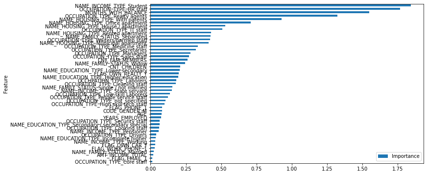

```python
features = x.columns
coefficients = logistic_model.coef_[0]
logistic_importance = pd.DataFrame({'Feature': features, 'Importance': np.abs(coefficients)})
logistic_importance = logistic_importance.sort_values('Importance', ascending=True)
logistic_importance.plot(x='Feature', y='Importance', kind='barh', figsize=(10, 6))
```

Even though the data has a good weighted F1 and precision score, this is because of the imbalanced data. If we look at the recall and f1 scores for bads, it's very poor because there are so few bads in the dataset, and as a result, the model is going to be able to predict goods much better than it can predict bads.

However, there is a remedy! And that remedy is oversampling, so that we can have an equal number of goods and bads. This way, the model will be able to predict bads better.

```python
x.dtypes
```

```
MONTHS_WITH_BALANCE                                  float64
CNT_CHILDREN                                         float64
AMT_INCOME_TOTAL                                     float64
CNT_FAM_MEMBERS                                      float64
AGE                                                  float64
YEARS_EMPLOYED                                       float64
CODE_GENDER_M                                          int64
FLAG_OWN_CAR_Y                                         int64
FLAG_OWN_REALTY_Y                                      int64
NAME_EDUCATION_TYPE_Higher education                   int64
NAME_EDUCATION_TYPE_Incomplete higher                  int64
NAME_EDUCATION_TYPE_Lower secondary                    int64
NAME_EDUCATION_TYPE_Secondary / secondary special      int64
NAME_INCOME_TYPE_Pensioner                             int64
NAME_INCOME_TYPE_State servant                         int64
NAME_INCOME_TYPE_Student                               int64
NAME_INCOME_TYPE_Working                               int64
NAME_FAMILY_STATUS_Married                             int64
NAME_FAMILY_STATUS_Separated                           int64
NAME_FAMILY_STATUS_Single / not married                int64
NAME_FAMILY_STATUS_Widow                               int64
NAME_HOUSING_TYPE_House / apartment                    int64
NAME_HOUSING_TYPE_Municipal apartment                  int64
NAME_HOUSING_TYPE_Office apartment                     int64
NAME_HOUSING_TYPE_Rented apartment                     int64
NAME_HOUSING_TYPE_With parents                         int64
FLAG_WORK_PHONE_1                                      int64
FLAG_PHONE_1                                           int64
FLAG_EMAIL_1                                           int64
OCCUPATION_TYPE_Cleaning staff                         int64
OCCUPATION_TYPE_Cooking staff                          int64
OCCUPATION_TYPE_Core staff                             int64
OCCUPATION_TYPE_Drivers                                int64
OCCUPATION_TYPE_HR staff                               int64
OCCUPATION_TYPE_High skill tech staff                  int64
OCCUPATION_TYPE_IT staff                               int64
OCCUPATION_TYPE_Laborers                               int64
OCCUPATION_TYPE_Low-skill Laborers                     int64
OCCUPATION_TYPE_Managers                               int64
OCCUPATION_TYPE_Medicine staff                         int64
OCCUPATION_TYPE_Private service staff                  int64
OCCUPATION_TYPE_Realty agents                          int64
OCCUPATION_TYPE_Sales staff                            int64
OCCUPATION_TYPE_Secretaries                            int64
OCCUPATION_TYPE_Security staff                         int64
OCCUPATION_TYPE_Waiters/barmen staff                   int64
OCCUPATION_TYPE_not_specified                          int64
dtype: object
```

```python
cat_cols = []
for col in x.columns:
    if x[col].dtype == 'int64':
        cat_cols.append(True)
    else:
        cat_cols.append(False)
print(cat_cols)
```

```
[False, False, False, False, False, False, True, True, True, True, True, True, True, True, True, True, True, True, True, True, True, True, True, True, True, True, True, True, True, True, True, True, True, True, True, True, True, True, True, True, True, True, True, True, True, True, True]
```

```python
from imblearn.over_sampling import SMOTENC
smotenc = SMOTENC(categorical_features = cat_cols, random_state = 42)
x_oversample, y_oversample = smotenc.fit_resample(x_train, y_train)
```

```python
y_oversample.value_counts()
```

```
0    18237
1    18237
Name: GOOD_BAD, dtype: int64
```

## Oversampling Data

Why is data oversampled? In cases similar to what we have, we want to have equal representation of class instances so that a model can better predict the lesser-represented instances. In all the models we fit, we are concerned with how well the model can predict bads, and that is the underrepresented class instance.

In Python, SMOTENC is a commonly used library used to oversample data. It's an acronym for Synthetic Minority Over-Sampling Technique for Nominal and Continuous, and in our case, we put all the nominal variables (which are integers because of dummy coded) into the formula so that the entire dataset can be oversampled with respect to those variables.

```python
logistic_model_oversample = LogisticRegression(max_iter = 1000).fit(x_oversample, y_oversample)
y_pred_test_oversample = logistic_model_oversample.predict(x_test)
y_pred_train_oversample = logistic_model_oversample.predict(x_train)
print("Training oversample accuracy: ", accuracy_score(y_train, y_pred_train_oversample))
print("Testing oversample accuracy: ", accuracy_score(y_test, y_pred_test_oversample))
logistic_oversample_report = classification_report(y_test, y_pred_test_oversample)
print(logistic_oversample_report)
f1_score_log_test = f1_score(y_test, y_pred_test_oversample, average = 'weighted')
print("F1 score: ", f1_score_log_test)
precision_log_test = precision_score(y_test, y_pred_test_oversample, average = 'weighted')
print("Precision score: ", precision_log_test)
#the oversampled data shows a worse precision score but better recall score for bads after oversampling, which is better for real-life scenarios because recall = correctly identified bads / total actual bads
```

```
Training oversample accuracy:  0.6790352504638218
Testing oversample accuracy:  0.6779422128259338
              precision    recall  f1-score   support

           0       0.90      0.67      0.76      7816
           1       0.37      0.73      0.49      2117

    accuracy                           0.68      9933
   macro avg       0.63      0.70      0.63      9933
weighted avg       0.79      0.68      0.71      9933

F1 score:  0.7061213155917635
Precision score:  0.7865698042498648
```

```python
logistic_train_report = classification_report(y_train, y_pred_train_oversample)
print(logistic_train_report)
f1_score_log_train = f1_score(y_train, y_pred_train_oversample, average = 'weighted')
print("F1 score: ", f1_score_log_train)
precision_log_train = precision_score(y_train, y_pred_train_oversample, average = 'weighted')
print("Precision score: ", precision_log_train)
```

```
              precision    recall  f1-score   support

           0       0.91      0.66      0.76     18237
           1       0.38      0.76      0.50      4940

    accuracy                           0.68     23177
   macro avg       0.64      0.71      0.63     23177
weighted avg       0.80      0.68      0.71     23177

F1 score:  0.7075402430993416
Precision score:  0.7957934564235586
```

For the predicted training data, we have a worse precision score but better recall and f1 scores after oversampling. This is better for real-life data because we are able to correctly identify bads in the entire set of bads better, and we won't give people credit cards unnecessarily. As a result of this drasticaly better recall score, we have a better f1 score for predicted bads.

Let's visualize the data we have above with a confusion matrix.

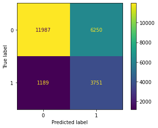

```python
from sklearn.metrics import ConfusionMatrixDisplay
confusion_matrix_log = confusion_matrix(y_train, y_pred_train_oversample)
cm_plot_log = ConfusionMatrixDisplay(confusion_matrix_log)
cm_plot_log.plot()
plt.show()
```

## K-Fold Cross Validation

The purpose of k-fold cross validation is to create "k" different folds within a given dataset, of which, k-1 folds are used for training data, and the remaining 1 fold is used for testing data. This process is repeated k times. It doesn't make the data dependent on any train/test split, which allows the model to be more robust.

Because the original dataset is imbalanced, I will be using a pipeline which overasamples the data while holding out data for training/testing folds. I will be doing this for all of my models.

```python
from imblearn.pipeline import Pipeline
from sklearn.model_selection import StratifiedKFold, cross_validate
logistic_steps = [('over', SMOTENC(categorical_features = cat_cols)), ('model', logistic_model)]
pipeline = Pipeline(steps=logistic_steps)
cv = StratifiedKFold(n_splits=5)
scoring = ["accuracy", "roc_auc", "precision", "recall", "f1_weighted"]
scores = cross_validate(pipeline, x_train, y_train, scoring=scoring, cv=cv, n_jobs=-1, return_train_score = True)
print(scores)
```

```
{'fit_time': array([10.80047727, 11.04685616, 10.71319103, 10.81439996, 11.07183003]), 'score_time': array([0.01686788, 0.01294899, 0.01810408, 0.02169299, 0.01114416]), 'test_accuracy': array([0.67817084, 0.68550475, 0.6806904 , 0.68220065, 0.6798274 ]), 'train_accuracy': array([0.68151664, 0.67892…
```

```python
for key, value in scores.items():
    print("Logistic model", key, "mean:", np.mean(value), ", std. dev:", np.std(value))
#looking @ training metrics:
#accuracy = 0.6815, roc_auc = 0.7767, precision = 0.3760, recall = 0.7488, f1 = 0.7097
```

```
Logistic model fit_time mean: 10.889350891113281 , std. dev: 0.1432864322905211
Logistic model score_time mean: 0.016151618957519532 , std. dev: 0.003751356747265711
Logistic model test_accuracy mean: 0.6812788058001124 , std. dev: 0.0024827657493959434
Logistic model train_accuracy mean: 0.6815808482841168 , std. dev: 0.0029191130777549545
Logistic model test_roc_auc mean: 0.7727639646105002 , std. dev: 0.00911611306846298
Logistic model train_roc_auc mean: 0.7766582272624647 , std. dev: 0.004055070311175374
Logistic model test_precision mean: 0.3753297185552752 , std. dev: 0.0030885037306186258
Logistic model train_precision mean: 0.37601210884190917 , std. dev: 0.002694517117212595
Logistic model test_recall mean: 0.7459514170040487 , std. dev: 0.021867970487135884
Logistic model train_recall mean: 0.7488360323886638 , std. dev: 0.004416482637504325
Logistic model test_f1_weighted mean: 0.7093114935753855 , std. dev: 0.002152426999686002
Logistic model train_f1_weighted mean: 0.709650292485178 , std. dev: 0.002573183481177498
```

The next step after this would be to hyperparametrize the model, but the logistic regression model is simple enough that we don't have to hyperparametrize it. We are now ready to move onto our next model.

# Quadratic Discriminant Analysis

Quadratic Discriminant Analysis models try to predict class distributions using Bayes Theorem, and this is the next model I will fit my data to. Just like logistic regression, this model doesn't have any hyperparameters to tune.

```python
from sklearn.discriminant_analysis import QuadraticDiscriminantAnalysis
qda_model = QuadraticDiscriminantAnalysis().fit(x_train, y_train)
y_qda_train_pred = qda_model.predict(x_train)
y_qda_test_pred = qda_model.predict(x_test)
print("Training accuracy: ", accuracy_score(y_train, y_qda_train_pred))
print("Testing accuracy: ", accuracy_score(y_test, y_qda_test_pred))
qda_report = classification_report(y_test, y_qda_test_pred)
print(qda_report)
f1_score_qda = f1_score(y_test, y_qda_test_pred, average = 'weighted')
print("F1 Score: ", f1_score_qda)
precision_score_qda = precision_score(y_test, y_qda_test_pred, average = 'weighted')
print("Precision Score: ", precision_score_qda)
```

```
Training accuracy:  0.7592872244035035
Testing accuracy:  0.7534481022853116
              precision    recall  f1-score   support

           0       0.81      0.89      0.85      7816
           1       0.38      0.25      0.30      2117

    accuracy                           0.75      9933
   macro avg       0.60      0.57      0.58      9933
weighted avg       0.72      0.75      0.73      9933

F1 Score:  0.7339320687363221
Precision Score:  0.7224704871574008
```

```python
#same for training data
qda_train_report = classification_report(y_train, y_qda_train_pred)
print(qda_train_report)
f1_score_qda_train = f1_score(y_train, y_qda_train_pred, average = 'weighted')
print("F1 Score: ", f1_score_qda_train)
precision_score_qda_train = precision_score(y_train, y_qda_train_pred, average = 'weighted')
print("Precision Score: ", precision_score_qda_train)
```

```
              precision    recall  f1-score   support

           0       0.82      0.89      0.85     18237
           1       0.41      0.29      0.34      4940

    accuracy                           0.76     23177
   macro avg       0.61      0.59      0.60     23177
weighted avg       0.73      0.76      0.74     23177

F1 Score:  0.7431734218166146
Precision Score:  0.7334288875770927
```

We can see similar trends to the QDA as we observed with the logistic regression model, because they're both similar enough models.

## Oversample Data

```python
#oversample data
qda_os = QuadraticDiscriminantAnalysis().fit(x_oversample, y_oversample)
y_qda_os_train_pred = qda_os.predict(x_train)
y_qda_os_test_pred = qda_os.predict(x_test)
print("Training oversample accuracy: ", accuracy_score(y_train, y_qda_os_train_pred))
print("Testing oversample accuracy: ", accuracy_score(y_test, y_qda_os_test_pred))
qda_os_report = classification_report(y_test, y_qda_os_test_pred)
print(qda_os_report)
f1_score_qda_os = f1_score(y_test, y_qda_os_test_pred, average = 'weighted')
print("F1 Score oversample: ", f1_score_qda_os)
precision_score_qda_os = precision_score(y_test, y_qda_os_test_pred, average = 'weighted')
print("Precision Score oversample: ", precision_score_qda_os)
```

```
Training oversample accuracy:  0.5510635543858136
Testing oversample accuracy:  0.5503875968992248
              precision    recall  f1-score   support

           0       0.86      0.51      0.64      7816
           1       0.28      0.71      0.40      2117

    accuracy                           0.55      9933
   macro avg       0.57      0.61      0.52      9933
weighted avg       0.74      0.55      0.59      9933

F1 Score oversample:  0.5891907037817732
Precision Score oversample:  0.7397285790708384
```

```python
#training data
qda_os_report_train = classification_report(y_train, y_qda_os_train_pred)
print(qda_os_report_train)
f1_score_qda_os = f1_score(y_train, y_qda_os_train_pred, average = 'weighted')
print("F1 Score oversample: ", f1_score_qda_os)
precision_score_qda_os = precision_score(y_train, y_qda_os_train_pred, average = 'weighted')
print("Precision Score oversample: ", precision_score_qda_os)
```

```
              precision    recall  f1-score   support

           0       0.87      0.50      0.64     18237
           1       0.28      0.72      0.41      4940

    accuracy                           0.55     23177
   macro avg       0.58      0.61      0.52     23177
weighted avg       0.75      0.55      0.59     23177

F1 Score oversample:  0.5893684607046596
Precision Score oversample:  0.7456947896982633
```

So far, this model is looking the shakiest when looking at the metrics. Just like the logistic regression, let's visualize the data with a confusion matrix.

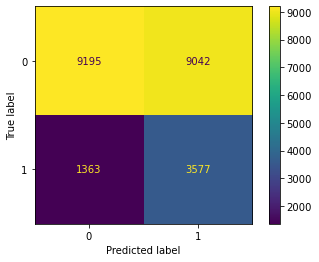

```python
confusion_matrix_qda = confusion_matrix(y_train, y_qda_os_train_pred)
cm_plot_qda = ConfusionMatrixDisplay(confusion_matrix_qda)
cm_plot_qda.plot()
plt.show()
```

Due to the simplicity of this model, we have a lot more bads being predicted than the true number of bads. This also can be a problem for credit card companies because if too many people are classified as being bad when they are actually good, the company will lose out on revenue because they won't be issuing cards to people who deserve them.